Introduction

Brief introduction into the Bella App IS a women’s health and wellness platform that tracks user activity, sleep, stress, and menstrual cycles to provide personalized health insights and guidance. It syncs with Bellabeat’s smart devices, like the Ivy, Leaf, and Time, to gather biometric data and offers features such as cycle tracking, pregnancy support, guided meditations, and personalized workout and nutrition plans through a premium membership. Core features Activity tracking: The app logs your daily movement and exercise based on data from Bellabeat devices like the Ivy and Leaf. Sleep tracking: When wearing a Bellabeat tracker, the app monitors your sleep patterns, including time spent in light and deep sleep. Menstrual and reproductive health tracking: A key feature is the ability to track your menstrual cycle, fertile days, and ovulation. A dedicated app, IVY Period & Pregnancy Tracker, also provides detailed reproductive health insights. Hydration tracking: If synced with a Bellabeat Spring smart water bottle, the app tracks your water intake and can send reminders to help you stay hydrated. Mindfulness and stress management: The app offers guided meditations and breathing exercises to help users reduce stress. Pregnancy tracking: For pregnant users, the app can be used to track fetal kicks and provides a prenatal calendar with information on baby development. Why are these features important valuable proposition of the product? The various features of the Bellabeat app form a compelling value proposition by specifically addressing the holistic health needs and concerns of women. The product differentiates itself from competitors by integrating health metrics with the female body and cycle, offering a personalized and empowering experience.

### **ASK**

Business Task

The purpose of this analysis is to explore and analyze Fitbit fitness tracker data to identify patterns in users’ daily activity, distance covered, and calories expenditure, by the usage of these parameters, Bellabeat can:

Gain insights into user lifestyle habits (steps, distance, calories, and weekly/daily trends).

Identify opportunities to enhance the Bella App by following and replicating popular features in the fitbit app.

Provide fitness advice and recommendations which is user specific in order to improve health, activity, and wellness outcomes.

By Observing and analyzing the fitbit app it can give key insights where the Bella app can improve and develope their own total all in one women specific fitness lifestyle device S

Summary of Data Analysis

This report summarizes and analyses data collected from FitBit Fitness Tracker Data which was retrieved from Kaggle website click here [link] (https://www.kaggle.com/datasets/arashnic/fitbit).

The area of observations/ analysis goes as following

Steps taken analysis aims:

- To determine the minimum, maximum, mean values of daily steps recorded by the fitbit device
- To identify the number and percentage of users whose daily recorded steps exceed and less than that of average steps taken value,
- To determine which day of the week has most and least recorded steps taken on the device
- To determine which week of weekly data has the highest and lowest amount of recorded steps taken by the fitbit device
- To determine which users are most and least active than others by tracking the user IDs with highest and lowest recorded total steps

Distance analysis aims

- To determine the minimum, maximum, mean values of distance covered recorded by the fitbit device
- To identify the number and percentage of users whose daily recorded distance covered exceed and less than that of average distance covered ,
- To determine which day of the week has most recorded and least distance covered on the device
- To determine which week of weekly data has the highest and lowest amount of recorded distance covered fitbit device
- To determine which users are most and least active than others,by tracking the user IDs with highest and lowest distance covered

Calories used analysis aims

- To determine the minimum, maximum, mean values of calories used recorded by the fitbit device
- To identify the number and percentage of users whose daily recorded distance covered exceed and less than that of average calories used
- To determine which day of the week has most recorded and least calories used on the device
- To determine which week of weekly data has the highest and lowest amount of recorded calories used by fitbit device
- To determine which users used up the most and least calories

### **PREPARE**

[output not shown]

#### **Cleaning and formatting of dataset**

When cleaning and formatting the data, i saw that ActivityDate columns was in character format, so had to change it to date format m%d%y format, all other columns was in double/numerical format which was correct

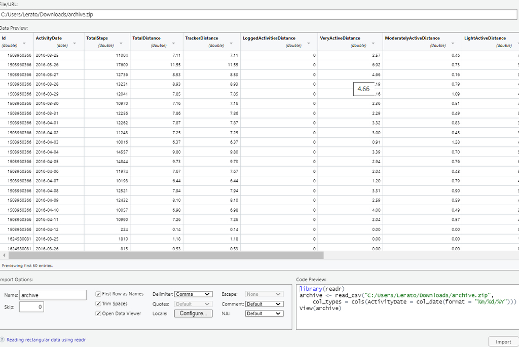

#### **Getting the general information and layout of database**

str(archive) spc_tbl_ [457 × 15] (S3: spec_tbl_df/tbl_df/tbl/data.frame)

$ Id : num [1:457] 1.5e+09 1.5e+09 1.5e+09 1.5e+09 1.5e+09 …

$ ActivityDate : Date[1:457], format: “2016-03-25” “2016-03-26” “2016-03-27” “2016-03-28” …

$ TotalSteps : num [1:457] 11004 17609 12736 13231 12041 …

$ TotalDistance : num [1:457] 7.11 11.55 8.53 8.93 7.85 …

$ TrackerDistance : num [1:457] 7.11 11.55 8.53 8.93 7.85 …

$ LoggedActivitiesDistance: num [1:457] 0 0 0 0 0 0 0 0 0 0 …

$ VeryActiveDistance : num [1:457] 2.57 6.92 4.66 3.19 2.16 …

$ ModeratelyActiveDistance: num [1:457] 0.46 0.73 0.16 0.79 1.09 ….

$ LightActiveDistance : num [1:457] 4.07 3.91 3.71 4.95 4.61 …

$ SedentaryActiveDistance : num [1:457] 0 0 0 0 0 0 0 0 0 0 …

$ VeryActiveMinutes : num [1:457] 33 89 56 39 28 30 33 47 40 15 …

$ FairlyActiveMinutes : num [1:457] 12 17 5 20 28 13 12 21 11 30 …

$ LightlyActiveMinutes : num [1:457] 205 274 268 224 243 223 239 200 244 314 …

$ SedentaryMinutes : num [1:457] 804 588 605 1080 763 …

$ Calories : num [1:457] 1819 2154 1944 1932 1886 …

### **PROCESS**

#### **Inserting a new column for the day of the week a particular date resides**

archive %>% mutate(day_of_week =wday(ActivityDate, label = TRUE, abbr = FALSE))

#The new column was insterted so that we track weekly, daily, and weekday use of the app by users, so we can track on which days are app users are most, least active according to the recording fitbit app

> colnames(archive)

#To confirm that new column named day_of_week was added to the dataframe

[1] “Id” “ActivityDate”  
“TotalSteps” “TotalDistance” “TrackerDistance” LoggedActivitiesDistance” “VeryActiveDistance”  
“ModeratelyActiveDistance” “LightActiveDistance” “SedentaryActiveDistance” “VeryActiveMinutes” “FairlyActiveMinutes” “LightlyActiveMinutes” “SedentaryMinutes” “Calories”  
“day_of_week”

### **ANALYZING AND SHARING**

#### **Arranging descending order of total daily steps taken from the fitbit app for the monthly cycle**

> archive %>% filter(TotalSteps >0) %>% arrange(desc(TotalSteps)) %>% select(Id, TotalSteps,TotalDistance,Calories,day_of_week))

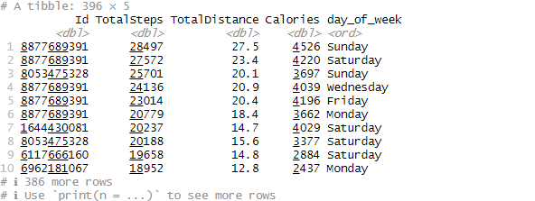

#### **Arranging total steps taken from lowest recorded daily steps on the fitbit app**

> archive %>% filter(TotalSteps >0) %>% arrange(TotalSteps) %>% select(Id, TotalSteps,TotalDistance,Calories,day_of_week))

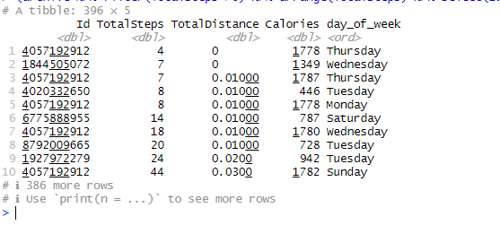

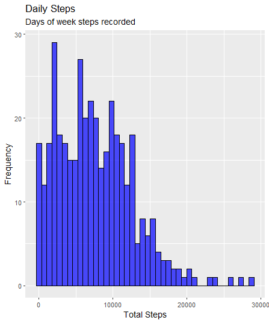

Histogram of Total Steps

Inspection of the range of values in the database was performed, database was filtered, sorted to visualise extreme values of amount of steps taken , exculding all zero values during the one month cycle. Reasons for excluding zero values, with zero values there are too many unknown variables for why the individual didnt record any steps,it maybe due to sickness, device malfunctioning, theft etc.. thus unknown variable cannot be taken into account in calculations.Few important columns of interest namely (Id, TotalSteps, TotalDistance, Calories and day_of_week to see a pattern or correlation forming with the results were selected to be viewed

#### **Selecting and filtering recorded total steps per app user which is greater and equal to the average daily steps taken on fitbit app**

> archive %>% filter(TotalSteps >= (archive %>% filter(TotalSteps > 0) %>% summarise(avg_daily_steps = mean(TotalSteps, na.rm = TRUE)) %>% pull(avg_daily_steps)))

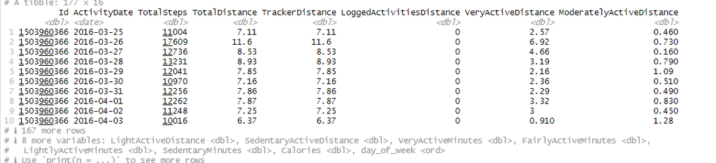

The average amount of daily steps was calculated, a pipe function was created in which it used the archive database as the location where the data is going to pulled from Rows were filered in which the total steps values was greater than zero value and then filtered for the number of total daily steps taken that is equal to or greater than the average total steps recorded for the month from the above results it indicates there are a total of 177 entries in the fitbit database that recorded the daily total steps that are equal and greater than the average daiy total steps taken for the one month cycle From the above calculations there are a total of 396 total entries for total steps greater than zero, recorded in the databse for the one month cyclce thus to get the percentage value of total steps greater than or equal to the average daily total steps is the below calculation

sum(177/396)*100

[1] 44.69697

#percentage for total steps taken that is less than the montly average total steps

> 100-44.69697

[1] 55.30303

> ggplot(steps_data, aes(x = ““, y = percentage, fill = category)) + + geom_bar(width = 1, stat =”identity”) + + coord_polar(“y”) + + labs(title = “Steps Above vs Below Monthly Average Steps”) + + theme_void() + + theme(legend.title = element_blank()) + + geom_text(aes(label = paste0(percentage, “%”)), # show 44.7 and 55.3 + position = position_stack(vjust = 0.5))

[figure not shown]

Pie chart of Totalsteps above and below montly avaerage

#### **Selecting and filtering for average steps taken by each indiviual fitbit app user**

> archive %>% filter(TotalSteps > 0) %>% group_by(Id) %>% summarise(average_daily_steps_ID = mean(TotalSteps, na.rm = TRUE))

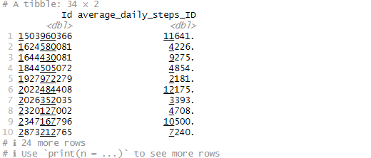

#### **Calculating the average steps taken per week day on the fitbit app for the one month cycle**

> Average_steps_per_weekday <- archive %>% + filter(TotalSteps > 0) %>% + group_by(day_of_week) %>% + summarise(average_steps_weekday = mean(TotalSteps)) %>% + arrange(factor(day_of_week, + levels = c(“Monday”, “Tuesday”, “Wednesday”, “Thursday”, “Friday”, “Saturday”, “Sunday”)))

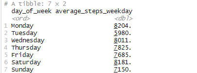

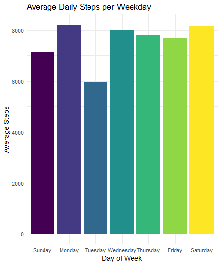

Bar graph of average daily steps per weekday

A new vector called day_of_week average was created pulling data from archive database

Total steps were filtered for total steps great zero values The group by functions tells R studios to divide my data into groups ( days of the week) based on a variable like day_of_week e.g Saturday Sunday. Summarise(average_steps_weekday = mean(TotalSteps)) basically this function tells us for each day of the week calculate the average of the total steps taken Arrange(factor(day_of_week, levels = c(…) function, R studio will arrange each day of the week alphabetically , by placing levels =(c,,,) inside the function , you direct R studios which order you want the results to be presented in The new column is named average_steps_weekday

#### **Calculating the average steps taken weekly on the fitbit app for the one month cycle**

> weekly_avg_steps <- archive %>% filter(TotalSteps > 0) %>% + mutate(week = floor_date(ActivityDate, unit = “week”)) %>% # floor_date sets the week start + group_by(week) %>% summarise(average_steps = mean(TotalSteps, na.rm = TRUE)) %>% arrange(week)

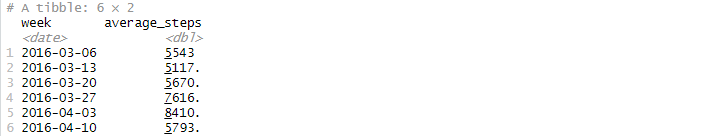

TotalSteps > 0, total steps are filtered for values greater than zero mutate(week = floor_date(ActivityDate, unit = “week”))floor_date() takes a date and puts it in the start of the week group_by week the function groups your dataset weekly the summarise(average_steps = mean(TotalSteps, na.rm = TRUE)) calculate, the average number of steps per day and average for each week we grouped na.rm = TRUE ignores missing values arrange(week) sort the results in chronological order (weeks).

> ggplot(weekly_avg_steps, aes(x = week, y = average_steps, fill = as.factor(week))) + + geom_col() + + labs( + title = “Average Daily Steps per Week”, + x = “Week”, + y = “Average Steps” + )

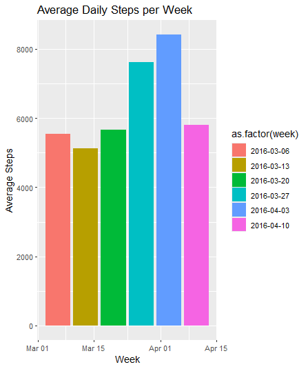

Bar graph of average daily steps per week

#### **Arranging ascending order of total distance covered from the fitbit app for the monthly cycle**

> archive %>% filter(TotalDistance >0) %>% arrange(TotalDistance) %>% select(Id, TotalSteps,TotalDistance,Calories,day_of_week) print(archive %>% filter(TotalDistance >0) %>% arrange(TotalDistance) %>% select(Id, TotalSteps,TotalDistance,Calories,day_of_week))

[figure not shown]

The code to select and filter out for extreme maximum and minimum distance covered, during the one month cycle. the code used was to filter and select funcions in which the code exculded all zero values reasoning for exculding zero values, with zero vlaues there are too many unknown variables for why the indiviual didnt record any distance covered,it maybe we due to sickness, device malfunctioning, theft etc.. thus we can take into account unknown variables. Few important columns of interest namely (Id, TotalSteps, TotalDistance, Calories and day_of_week) were selected in order to see a pattern or correlation forming with the results)

#### **Arranging descending order of total distance covered from the fitbit app for the monthly cycle**

> archive %>% filter(TotalDistance >0) %>% arrange(desc(TotalDistance)) %>% select(Id, TotalSteps,TotalDistance,Calories,day_of_week)

> print(archive %>% filter(TotalDistance >0) %>% arrange(desc(TotalDistance)) %>% select(Id, TotalSteps,TotalDistance,Calories,day_of_week))

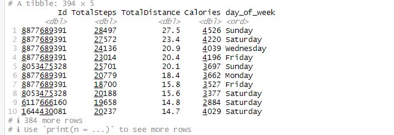

#### **Distrubtion of total distance covered by users from the fitbit app for the monthly cycle**

> archive %>% + filter(TotalDistance > 0) %>% + ggplot(aes(x = TotalDistance)) + + geom_histogram(binwidth = 1, fill = “blue”, color = “black”, alpha = 0.7) + + labs( + title = “Distribution of Daily Total Distance”, + x = “Total Distance”, + y = “Count of Days” + )

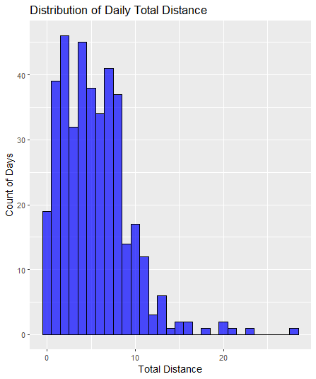

Histogram oftotal distance travelled by fitbit users

#### **Calculating the average daily total distance covered recorded on the fitbit app in the one month cycle**

> archive %>% filter(TotalDistance > 0) %>% summarise(average_daily_distance = mean(TotalDistance, na.rm = TRUE))

The average total distance covered or travelled was calculated, again we stated with our pipe in which we used the archive database as the location where the data is going to pulled from. Rows were filered for total distance values was greater than zero .Summarise function to create a small table where statstical calculation are performed, in which the average value of across the rows of the total distance column, na.rm = TRUE indcates the exculsion of all missing valuesin the calculations. New column name with the calculated average of total distance is called average_daily_distance

#### **Selecting and filtering recorded total distance covered per app user which is greater and equal to the average daily distance covered taken on fitbit app**

> archive %>% filter(TotalDistance >= (archive %>% filter(TotalDistance > 0) %>% summarise(avg_daily_distance = mean(TotalDistance, na.rm = TRUE)) %>% pull(avg_daily_distance)))

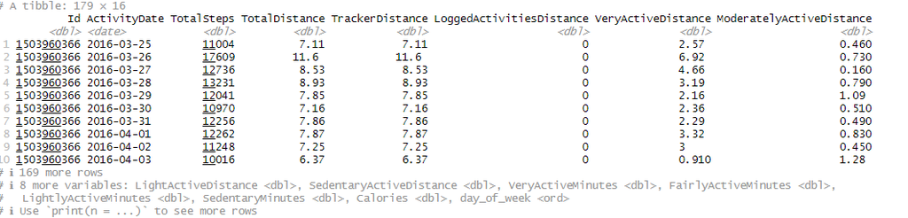

#percentage for distance travelled that is less than the montly for total average distance covered

> ggplot(distance_pct, aes(x = ““, y = percentage, fill = category)) + + geom_bar(stat =”identity”, width = 1, color = “white”) + + coord_polar(theta = “y”) + + labs(title = “Distance Travelled relation to average distance”) + + theme_void() + + geom_text(aes(label = paste0(round(percentage, 1), “%”)), + position = position_stack(vjust = 0.5)) + + scale_fill_manual(values = c(“red”, “blue”))

[figure not shown]

Pie chart of distance travelled above and below montly avaerage

#### **Selecting, filtering and sorting for average daily distance covered/ walked by each individual fitbit app user in descending order *

> average_daily_distance_ID <- archive %>% filter(TotalDistance > 0) %>% group_by(Id) %>% summarise(avg_daily_distance_ID = mean(TotalDistance, na.rm = TRUE)) %>% arrange(desc(avg_daily_distance_ID)) print( average_daily_distance_ID <- archive %>% filter(TotalDistance > 0) %>% group_by(Id) %>% summarise(avg_daily_distance_ID = mean(TotalDistance, na.rm = TRUE)) %>% arrange(desc(avg_daily_distance_ID)))

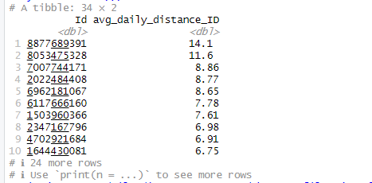

This code was ran in order to calculate the average daily distance per user (Id), then ranking them in desecndng order. Filter(TotalDistance > 0) removes in which its total distance value is zero. Group_by(Id) groups the databse in terms of user ID, all calculations will occur in terms of each unique user ID Summarise(avg_daily_distance_ID = mean(TotalDistance, na.rm = TRUE)), in this step the average of total distance covered by each user is calculated, the new cloumn created is called avg_daily_distance, each user ID will havve its own average daily distance

#### **Calculating the average distance covered per week day for the one month cycle for the fitbit app**

> Average_distance_per_weekday <- archive %>% filter(TotalDistance > 0) %>% group_by(day_of_week) %>% + summarise(average_distance_weekday = mean(TotalDistance, na.rm = TRUE)) %>% + arrange(factor(day_of_week, + levels = c(“Monday”, “Tuesday”, “Wednesday”, “Thursday”, “Friday”, “Saturday”, “Sunday”)))

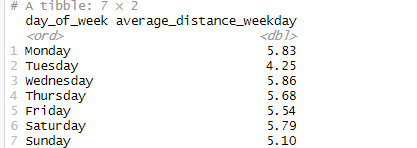

Vector called Average_distance_per_weekday was created pulling data from archive database Total distance covered were filtered for total distance values greater than zero The group by functions tells R studios to divide my data into groups ( days of the week) based on a variable like day_of_week e.g Saturday Sunday summarise(average_steps_weekday = mean(TotalDistance)) basically this function tells us for each day of the week calculate the average of the total distance covered Arrange(factor(day_of_week, levels = c(…) function, R studio will arrange each day of the week alphebatically , by placing levels =(c,,,) inside the function , you direct R studios which order you want the results to be presented in The new column is named day_of_week average_distance_weekday

#### **Bar chart of daily distance covered per week day for the one month cycle for the fitbit app**

> ggplot(Average_distance_per_weekday, aes(x = day_of_week, y = average_distance_weekday, fill = day_of_week)) + + geom_col() + + labs( + title = “Average Daily Distance per Weekday”, + x = “Day of Week”, + y = “Average Distance (km)” + )

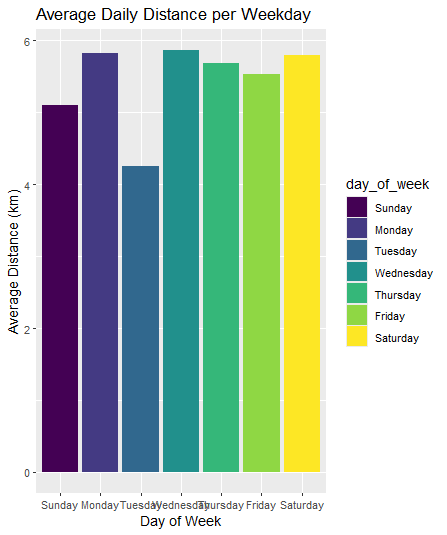

Bar chart of average distance travelled by app users for the one month cycle

#### **Calculating the average distance covered/ walked weekly on the fitbit app for the one month cycle**

> archive %>% + filter(TotalDistance > 0) %>% + mutate(week = floor_date(ActivityDate, unit = “week”)) %>% + group_by(week) %>% + summarise(average_weekly_distance = mean(TotalDistance, na.rm = TRUE)) %>% + arrange(week)

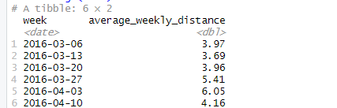

TotalDistance > 0, total distance travelled are filtered for values greater than zero Mutate(week = floor_date(ActivityDate, unit = “week”))floor_date() takes a date and puts it in the start of the weekgroup_by week This function groups your dataset weekly the summarise(average_weekly_distance = mean(TotalDistance, na.rm = TRUE)) calculate, the average distance walked or covered per day and the average for each week we grouped na.rm = TRUE ignores missing values arrange(week) sort the results in chronological order (weeks).

#### **Bar chart of the average distance covered/ walked weekly on the fitbit app for the one month cycle**

> ggplot(weekly_avg_distance, aes(x = week, y = average_weekly_distance, fill = as.factor(week))) + + geom_col() + + labs( + title = “Average Weekly Distance”, + x = “Week”, + y = “Average Distance (km)” + )

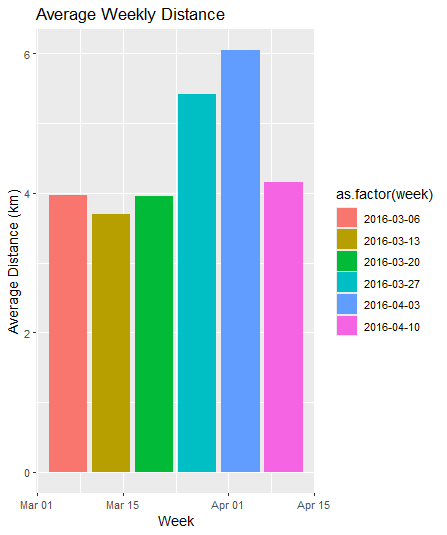

Bar chart of average distance travelled weekly by app users for the one month cycle

#### **Calculating the daily average calories expended by users for the one month cycle for the fitbit app arranging in descending order**

> archive %>% filter(Calories >0) %>% arrange(desc(Calories)) %>% select(Id, TotalSteps,TotalDistance,Calories,day_of_week)

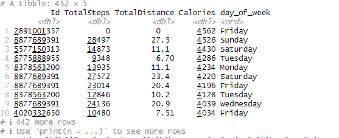

> archive %>% filter(Calories >0) %>% arrange(desc(Calories)) %>% select(Id, TotalSteps,TotalDistance,Calories,day_of_week)

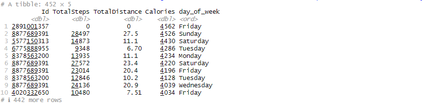

The range of values of the database of the database was inspected, the extreme maximum amd minium values amount for daily calories expenditure were of interest for the one month cycle. Filter and selection funcions were used which exculded all zero values. Exculding reasoning for exculding zero values, with zero values there are too many unknown variables for why the indiviual didnt record any calories expenditure,it maybe due to sickness, device malfunctioning, theft etc.. thus we can take into account unknown variables. Additionally a few selected columns of interest namely were filtered for namely (Id, TotalSteps, TotalDistance, Calories and day_of_week ) in order to see a pattern or correlation forming with different parameter readings

#### **Calculating the total average calories expended by all users for the one month cycle for the fitbit app**

The total average calories expenditure was calculated, a creation of a new pipe in which we used the archive database as the location where the data is going to pulled from. Rows were filtered for calories which its values was greater than zero. Summarize function to create a small table where statistical calculations can occur in which the mean value of the calories rows are calculated, na.rm = TRUE indicating the exculsion of all missing values. The new column name with our calculated average calories is called avg_daily_calories

#### **Calculating the number of users and viewing their user ID whose average calories expenditure is greater than the mean total calories for all the total users in a one month cycle for the fitbit app arranged in ascending order**

> avg_daily_calories_more_than_mean_asc <- archive %>% filter(Calories > 0) %>% group_by(Id) %>% summarise(average_daily_calories = mean(Calories, na.rm = TRUE)) %>% filter(average_daily_calories > mean(average_daily_calories)) %>% arrange(average_daily_calories)

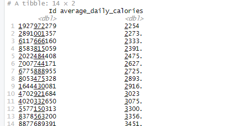

#percentage for of users whose calories expenditure is greater than the total daily average calories expenditure for all app user for the montly cycle arranged in ascending order

> sum(14/34)*100

[1] 41.17647

#percentage for of users whose calories expenditure is less or equal to the average daily total calories for all app user for the montly cycle arranged ascending order

> 100-41.17647

[1] 58.82353

Firstly a new pipe was created in the fist line of code called avg_daily_calories_more_than_mean_asc, the data pulled was from archive dataset we filtered for rows in which the calories values was greater than zero group_by(Id) groups the database in terms of user ID, all calculations will occur in terms of each unique user ID. Summarise(average_daily_calories = mean(Calories, na.rm = TRUE), in this step the average daily calories expenditure for each user is calculated, the new column created is called average_daily_calories , each user ID will have their own daily calories expenditure value, which is arranged in ascending ordering

#### **Filtering and selecting for daily calories expenditure of users whose readings are greater than or equal to total average calories expenditure of fitbit app users for the month cycle**

> archive %>% filter(Calories >= (archive %>% filter(Calories > 0) %>% summarise(avg_daily_calories = mean(Calories, na.rm = TRUE)) %>% pull(avg_daily_calories))) %>% select(Id, TotalSteps,TotalDistance,Calories,day_of_week

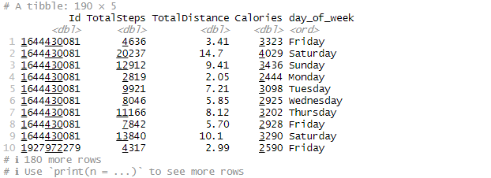

#### **Calculating the percentage of users whose daily average calories expenditure is greater than the total average of all users for the month cycle**

> sum(190/452)*100

[1] 42.0354

Firstly the daily average calories expended was calculated for all fitbit app users for the one month cycle for the fitbit app by exculding zero values. The calculation or code gave a total number of 452 recorded entries for calories daily usage. Afterwards the mean value of daily calories usages by all app users was calculated for the one month cycle, in the result was 2214 average calories expended daily by each app user results were filtered out for values greater or equal to the daily average calories expended by app users in this case there were 190 recorded entries for daily calories expenditures greater than the mean value, thus performed the above calculation to get the total percentage which is 42.0354%

> 100-42.0354

[1] 57.9646

> calories_pct <- data.frame( + category = c(“Calories above average”, “Calories below average”), + percentage = c(41.2, 58.8) + ) ggplot(calories_pct, aes(x = ““, y = percentage, fill = category)) + + geom_bar(stat =”identity”, width = 1, color = “white”) + + coord_polar(theta = “y”) + + labs(title = “Calories Expenditure vs Average (Monthly Cycle)”) + + theme_void() + + geom_text(aes(label = paste0(percentage, “%”)), + position = position_stack(vjust = 0.5)) + + scale_fill_manual(values = c(“green”, “orange”))

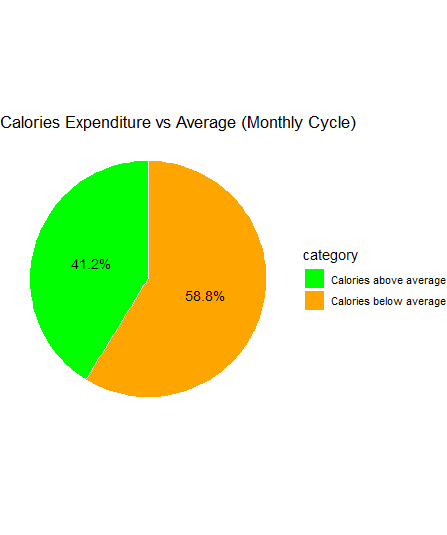

Pie chart of above and below calories average

This calculation is basically substracting 100% from the percentage usage of indiviuals whose daily calories reading is greater than or equal to the total averag of e daily calories expenditure of all app users

#### **Arranging in descending order the daily average calories expenditure by fitbit app users whose daily calories expenditure is greater than or equal to the average total mean value of all fitbit app users for the one month cycle**

> archive %>% filter(Calories >= (archive %>% filter(Calories > 0) %>% summarise(avg_daily_calories = mean(Calories, na.rm = TRUE)) %>% pull(avg_daily_calories))) %>% select(Id, TotalSteps,TotalDistance,Calories,day_of_week) %>% arrange(desc(Calories))

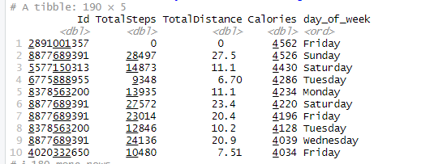

#### **Arranging in ascending order the daily average calories expenditure by fitbit app users whose daily calories expenditure is greater than or equal to the average total mean value of all fitbit app users for the one month cycle**

> archive %>% filter(Calories >= (archive %>% filter(Calories > 0) %>% summarise(avg_daily_calories = mean(Calories, na.rm = TRUE)) %>% pull(avg_daily_calories))) %>% select(Id, TotalSteps,TotalDistance,Calories,day_of_week) %>% arrange(Calories)

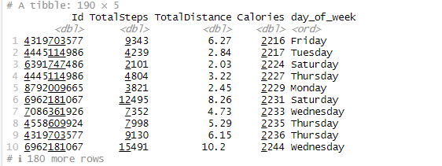

#### **Calculating the average daily calories expenditure per week day for the one month cycle for the fitbit app**

> Average_calories_per_weekday <- archive %>% + filter(Calories > 0) %>% + group_by(day_of_week) %>% + summarise(average_calories_weekday = mean(Calories, na.rm = TRUE)) %>% + arrange(factor(day_of_week, + levels = c(“Monday”, “Tuesday”, “Wednesday”, “Thursday”, + “Friday”, “Saturday”, “Sunday”)))

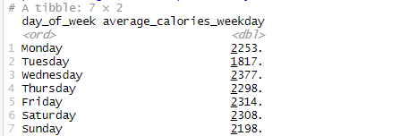

A vector called Average_calories_per_weekday was created pulling data from archive database Calories were filtered for values greater than zero The group by functions tells R studios to divide my data into groups ( days of the week) based on a variable like day_of_week e.g Saturday Sunday summarise( average_calories_weekday = mean(Calories)) basically this function tells us for each day of the week calculate the average of calories expenditure bu users Arrange(factor(day_of_week, levels = c(…) function, R studio will arrange each day of the week alphebatically , by placing levels =(c,,,) inside the function , you direct R studios which order you want the results to be presented in The new column is named day_of_week average_calories_weekday

#### **Bar graph of the average daily calories expenditure per week day for the one month cycle for the fitbit app**

> ggplot(Average_calories_per_weekday, aes(x = day_of_week, + y = average_calories_weekday, + fill = day_of_week)) + + geom_col() + + labs( + title = “Average Calories expenditure per Weekday”, + x = “Day of Week”, + y = “Average Calories” + )

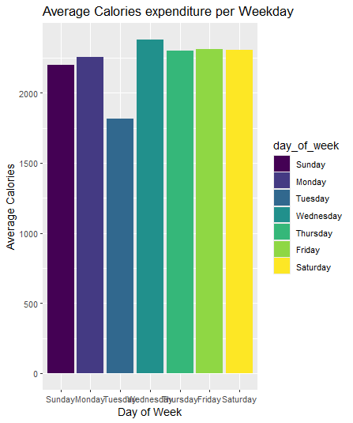

Bar graph of Calories used per weekday